# PracticalML

Daniela Varela

2/1/2021

## Overview

One thing that people regularly do is quantify how much of a particular activity they do, but they rarely quantify how well they do it. In this project, the goal will be to use data from accelerometers on the belt, forearm, arm, and dumbell of 6 participants.

## Load data

```r
train<-read.csv("https://d396qusza40orc.cloudfront.net/predmachlearn/pml-training.csv",header=T)
test<-read.csv("https://d396qusza40orc.cloudfront.net/predmachlearn/pml-testing.csv",header=T)
```

## Cleaning data

Reducing the variables that contain missing values.

```r
test <- test[, colSums(is.na(test)) == 0]
train <- train[, colSums(is.na(train)) == 0]

dim(test)
```

```
## [1] 20 60
```

```r
dim(train)
```

```
## [1] 19622    93
```

Remove unnecesary variables.

```r
test<-test[, -c(1:7)]
train<-train[, -c(1:7)]
```

## Partition of training data

```r
training  <- createDataPartition(train$classe, p=0.7, list=FALSE)
TrainSet <- train[training, ]
TestSet  <- train[-training, ]
dim(TrainSet)
```

```
## [1] 13737    86
```

```r
dim(TestSet)
```

```
## [1] 5885   86
```

Clear out variables with nearly zero variance.

```r
NZV <- nearZeroVar(TrainSet)
TrainSet <- TrainSet[, -NZV]
TestSet  <- TestSet[, -NZV]
dim(TrainSet)
```

```
## [1] 13737    53
```

```r
dim(TestSet)
```

```
## [1] 5885   53
```

53 variables are obtained after all the cleaning steps.

## Correlation analysis

A correlation among variables is analysed before the modeling.

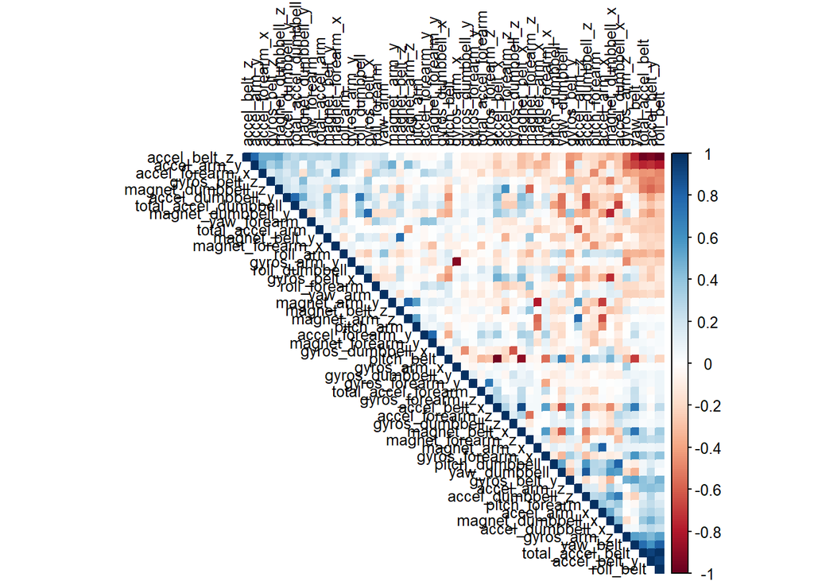

```r
matrix <- cor(select(TrainSet, -c("classe")))
corrplot(matrix, order = "FPC", method = "color", type = "upper",
         tl.cex = 0.8, tl.col = rgb(0, 0, 0))
```

The most correlated variables are shown in dark colors above. If we want to inspect what are the most correlated variables above a threshold, we could do something like this:

```r
mostCorrelated = findCorrelation(matrix, cutoff=0.75)
names(TrainSet)[mostCorrelated]
```

```
##  [1] "accel_belt_z"      "roll_belt"         "accel_arm_y"
##  [4] "accel_belt_y"      "total_accel_belt"  "accel_dumbbell_z"
##  [7] "accel_belt_x"      "pitch_belt"        "magnet_dumbbell_x"
## [10] "accel_dumbbell_y"  "magnet_dumbbell_y" "accel_dumbbell_x"
## [13] "accel_arm_x"       "accel_arm_z"       "magnet_arm_y"
## [16] "magnet_belt_z"     "accel_forearm_y"   "gyros_arm_x"
```

# MODEL

## 1. Decision Tree

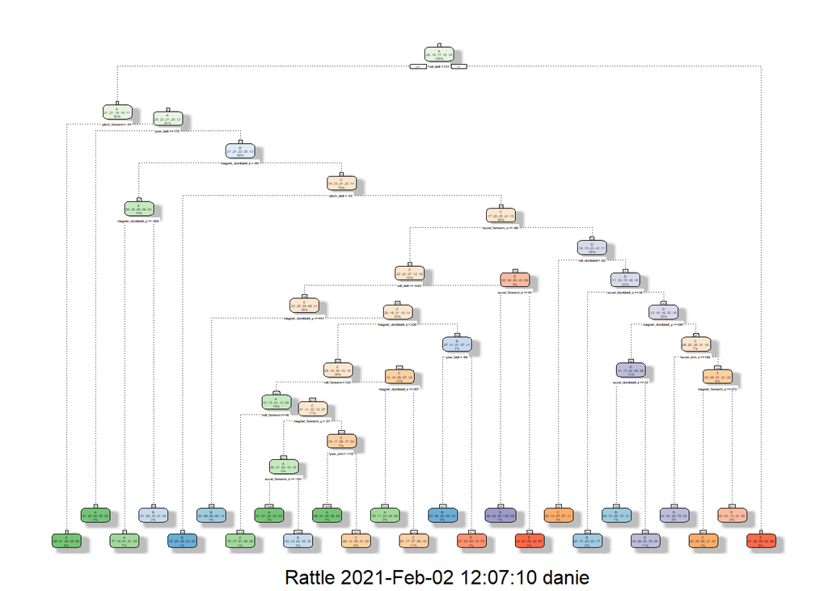

```r
set.seed(12345)
model1 <- rpart(classe ~ ., data=TrainSet, method="class")
fancyRpartPlot(model1)
```

### prediction

```r
prediction1 <- predict(model1, newdata=TestSet, type="class")
cm1 <- confusionMatrix(prediction1, TestSet$classe)
cm1
```

```
## Confusion Matrix and Statistics
##
##           Reference
## Prediction    A    B    C    D    E
##          A 1468  149   11   43   27
##          B   35  714   74   90  119
##          C   44  210  904  197  143
##          D  112   51   12  593   37
##          E   15   15   25   41  756
##
## Overall Statistics
##
##                Accuracy : 0.7536
##                  95% CI : (0.7424, 0.7646)
##     No Information Rate : 0.2845
##     P-Value [Acc > NIR] : < 2.2e-16
##
##                   Kappa : 0.6883
##
##  Mcnemar's Test P-Value : < 2.2e-16
##
## Statistics by Class:
##
##                      Class: A Class: B Class: C Class: D Class: E
## Sensitivity            0.8769   0.6269   0.8811   0.6151   0.6987
## Specificity            0.9454   0.9330   0.8778   0.9569   0.9800
## Pos Pred Value         0.8645   0.6919   0.6035   0.7366   0.8873
## Neg Pred Value         0.9508   0.9124   0.9722   0.9270   0.9352
## Prevalence             0.2845   0.1935   0.1743   0.1638   0.1839
## Detection Rate         0.2494   0.1213   0.1536   0.1008   0.1285
## Detection Prevalence   0.2885   0.1754   0.2545   0.1368   0.1448
## Balanced Accuracy      0.9112   0.7799   0.8794   0.7860   0.8394
```

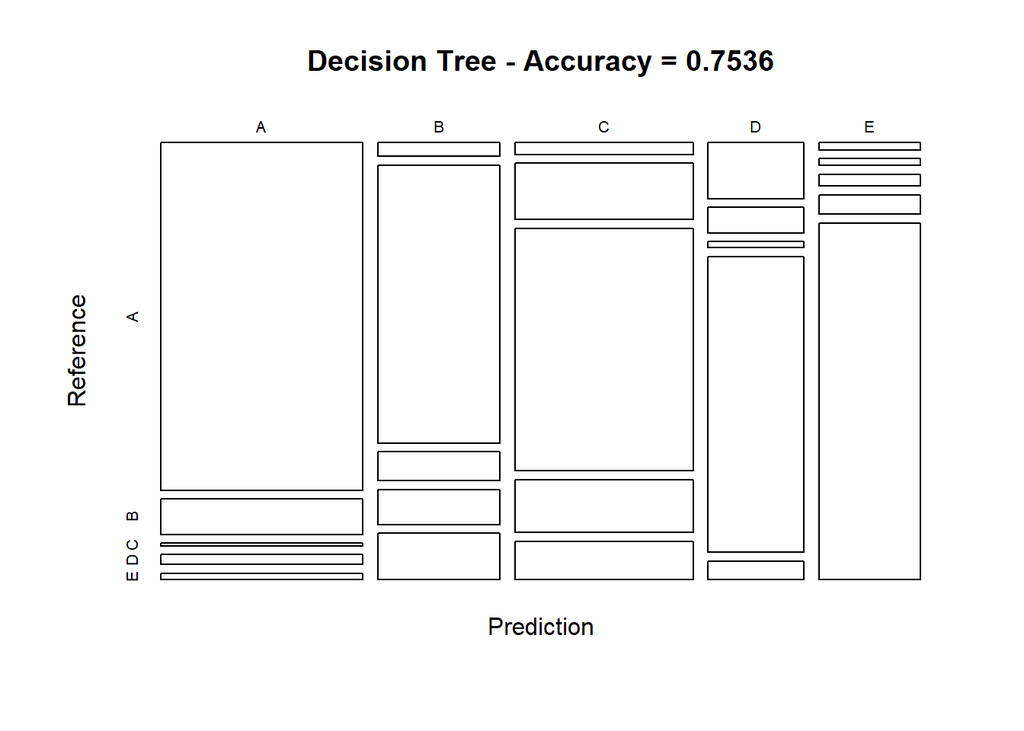

```r
plot(cm1$table, col = cm1$byClass,
     main = paste("Decision Tree - Accuracy =", round(cm1$overall['Accuracy'], 4)))
```

## 2. Random Forest

We will use **5-fold cross validation** when applying the algorithm.

```r
model2 <- train(classe ~ ., data=TrainSet, method="rf",
                trControl=trainControl(method="cv", 5, verboseIter=FALSE))

model2$finalModel
```

```
##
## Call:
##  randomForest(x = x, y = y, mtry = param$mtry)
##                Type of random forest: classification
##                      Number of trees: 500
## No. of variables tried at each split: 2
##
##         OOB estimate of  error rate: 0.76%
## Confusion matrix:
##      A    B    C    D    E  class.error
## A 3904    2    0    0    0 0.0005120328
## B   19 2634    5    0    0 0.0090293454
## C    1   23 2370    2    0 0.0108514190
## D    1    0   43 2205    3 0.0208703375
## E    0    0    2    4 2519 0.0023762376
```

### prediction

```r
prediction2 <- predict(model2, newdata=TestSet)
cm2 <- confusionMatrix(prediction2, TestSet$classe)
cm2
```

```
## Confusion Matrix and Statistics
##
##           Reference
## Prediction    A    B    C    D    E
##          A 1674    4    0    0    0
##          B    0 1132   11    0    0
##          C    0    3 1013   10    2
##          D    0    0    2  953    4
##          E    0    0    0    1 1076
##
## Overall Statistics
##
##                Accuracy : 0.9937
##                  95% CI : (0.9913, 0.9956)
##     No Information Rate : 0.2845
##     P-Value [Acc > NIR] : < 2.2e-16
##
##                   Kappa : 0.992
##
##  Mcnemar's Test P-Value : NA
##
## Statistics by Class:
##
##                      Class: A Class: B Class: C Class: D Class: E
## Sensitivity            1.0000   0.9939   0.9873   0.9886   0.9945
## Specificity            0.9991   0.9977   0.9969   0.9988   0.9998
## Pos Pred Value         0.9976   0.9904   0.9854   0.9937   0.9991
## Neg Pred Value         1.0000   0.9985   0.9973   0.9978   0.9988
## Prevalence             0.2845   0.1935   0.1743   0.1638   0.1839
## Detection Rate         0.2845   0.1924   0.1721   0.1619   0.1828
## Detection Prevalence   0.2851   0.1942   0.1747   0.1630   0.1830
## Balanced Accuracy      0.9995   0.9958   0.9921   0.9937   0.9971
```

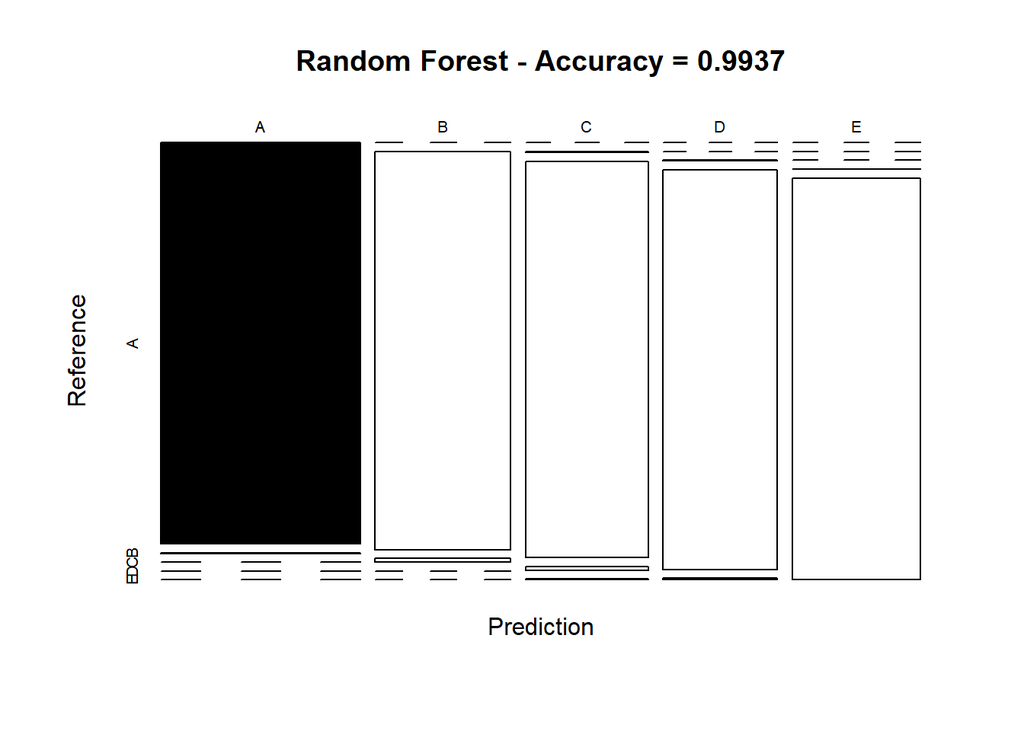

```r
plot(cm2$table, col = cm2$byClass,
     main = paste("Random Forest - Accuracy =",
                  round(cm2$overall['Accuracy'], 4)))
```

## Selected Model in the Test Data

```r
predictTEST <- predict(model2, newdata=test)
predictTEST
```

```
##  [1] B A B A A E D B A A B C B A E E A B B B
## Levels: A B C D E
```